# Homework Assignment 2

Dimensionality Reduction using PCA

Gunnar Sundberg - gsundberg3513@floridapoly.edu

Load the `tidyverse` and `factoextra` packages for this assignment.

```r
library(tidyverse)
library(factoextra)
```

# Problem 1

In this problem you will use data from the [EA Sports FIFA 18](https://en.wikipedia.org/wiki/FIFA_18) videogame.

- Get the dataset `fifa18.csv`:

```r
fifa18 <- read_csv("https://raw.githubusercontent.com/reisanar/datasets/master/fifa18.csv")
```

- Below is a sample of observations in this dataset:

```r
head(fifa18, 8)
```

| name | nationality | club | age | overall | potential | acceleration | aggression | agility | balance | ball_control | composure | crossing | curve | dribbling | finishing | free_kick_accuracy | gk_diving | gk_handling | gk_kicking | gk_positioning | gk_reflexes | heading_accuracy | interceptions | jumping | long_passing | long_shots | marking | penalties | positioning | … |
| --- | --- | --- | --- | --- | --- | --- | --- | --- | --- | --- | --- | --- | --- | --- | --- | --- | --- | --- | --- | --- | --- | --- | --- | --- | --- | --- | --- | --- | --- | --- |
| Cristiano Ronaldo | Portugal | Real Madrid CF | 32 | 94 | 94 | 89 | 63 | 89 | 63 | 93 | 95 | 85 | 81 | 91 | 94 | 76 | 7 | 11 | 15 | 14 | 11 | 88 | 29 | 95 | 77 | 92 | 22 | 85 | 95 | … |
| L. Messi | Argentina | FC Barcelona | 30 | 93 | 93 | 92 | 48 | 90 | 95 | 95 | 96 | 77 | 89 | 97 | 95 | 90 | 6 | 11 | 15 | 14 | 8 | 71 | 22 | 68 | 87 | 88 | 13 | 74 | 93 | … |
| Neymar | Brazil | Paris Saint-Germain | 25 | 92 | 94 | 94 | 56 | 96 | 82 | 95 | 92 | 75 | 81 | 96 | 89 | 84 | 9 | 9 | 15 | 15 | 11 | 62 | 36 | 61 | 75 | 77 | 21 | 81 | 90 | … |
| L. Suárez | Uruguay | FC Barcelona | 30 | 92 | 92 | 88 | 78 | 86 | 60 | 91 | 83 | 77 | 86 | 86 | 94 | 84 | 27 | 25 | 31 | 33 | 37 | 77 | 41 | 69 | 64 | 86 | 30 | 85 | 92 | … |
| M. Neuer | Germany | FC Bayern Munich | 31 | 92 | 92 | 58 | 29 | 52 | 35 | 48 | 70 | 15 | 14 | 30 | 13 | 11 | 91 | 90 | 95 | 91 | 89 | 25 | 30 | 78 | 59 | 16 | 10 | 47 | 12 | … |
| R. Lewandowski | Poland | FC Bayern Munich | 28 | 91 | 91 | 79 | 80 | 78 | 80 | 89 | 87 | 62 | 77 | 85 | 91 | 84 | 15 | 6 | 12 | 8 | 10 | 85 | 39 | 84 | 65 | 83 | 25 | 81 | 91 | … |
| De Gea | Spain | Manchester United | 26 | 90 | 92 | 57 | 38 | 60 | 43 | 42 | 64 | 17 | 21 | 18 | 13 | 19 | 90 | 85 | 87 | 86 | 90 | 21 | 30 | 67 | 51 | 12 | 13 | 40 | 12 | … |
| E. Hazard | Belgium | Chelsea | 26 | 90 | 91 | 93 | 54 | 93 | 91 | 92 | 87 | 80 | 82 | 93 | 83 | 79 | 11 | 12 | 6 | 8 | 8 | 57 | 41 | 59 | 81 | 82 | 25 | 86 | 85 | … |

1. Use the numerical attributes in this dataset to perform PCA. Get a summary of your PCA results (use the `summary()` function as shown in examples). Comment on your results.

```r
# dataframe with only numerical attributes
myfifa18 <- select(fifa18, -c(1:3))
```

Perform PCA:

```r
fifa18_pca <- prcomp(myfifa18, scale = T)
summary(fifa18_pca)
```

```
Importance of components:
                          PC1    PC2     PC3    PC4    PC5     PC6     PC7     PC8     PC9    PC10    PC11    PC12    PC13   PC14    PC15    PC16    PC17    PC18    PC19
Standard deviation     4.3689 2.2533 1.87212 1.3409 1.1826 1.07802 0.77922 0.68241 0.61347 0.56056 0.52255 0.49571 0.48476 0.4751 0.46636 0.45210 0.44772 0.42202 0.40620
Proportion of Variance 0.5159 0.1372 0.09473 0.0486 0.0378 0.03141 0.01641 0.01259 0.01017 0.00849 0.00738 0.00664 0.00635 0.0061 0.00588 0.00552 0.00542 0.00481 0.00446
Cumulative Proportion  0.5159 0.6531 0.74783 0.7964 0.8342 0.86564 0.88205 0.89463 0.90480 0.91330 0.92068 0.92732 0.93367 0.9398 0.94565 0.95117 0.95659 0.96140 0.96586
                          PC20    PC21    PC22    PC23    PC24    PC25    PC26    PC27    PC28    PC29   PC30    PC31    PC32    PC33    PC34    PC35    PC36    PC37
Standard deviation     0.38079 0.36100 0.35117 0.33028 0.30566 0.29417 0.28168 0.27648 0.26744 0.25356 0.2197 0.20730 0.19748 0.19620 0.17962 0.17661 0.16522 0.15585
Proportion of Variance 0.00392 0.00352 0.00333 0.00295 0.00253 0.00234 0.00214 0.00207 0.00193 0.00174 0.0013 0.00116 0.00105 0.00104 0.00087 0.00084 0.00074 0.00066
Cumulative Proportion  0.96978 0.97330 0.97664 0.97959 0.98211 0.98445 0.98659 0.98866 0.99059 0.99233 0.9936 0.99480 0.99585 0.99689 0.99776 0.99861 0.99934 1.00000
```

> Comments: In a dataset with 37 usable variables, we are able to capture ~90% of the variation using only the first 9 principal components.
2. Produce at least one **data visualization** to explain the results on PCA. (You can use the `factoextra` package for this and follow the examples discussed in class)

```r
fifa18_pca$rotation[ , 1:9]
```

```
                           PC1         PC2         PC3          PC4         PC5          PC6          PC7          PC8          PC9
age                -0.02769989 -0.07794780 -0.31005863  0.221521968 -0.16520125  0.573459175 -0.182020691  0.285043791 -0.017061251
overall            -0.10092180 -0.03999883 -0.43762722 -0.102088112  0.13032282 -0.086487625 -0.090683196  0.181762341 -0.077804630
potential          -0.07318750  0.01373997 -0.25056367 -0.275090610  0.23852611 -0.585772804  0.132936858  0.091750650 -0.101641350
acceleration       -0.16124182  0.13014736  0.11552000 -0.280481647  0.23508916  0.109800075 -0.325781803 -0.048729533 -0.091249260
aggression         -0.14529646 -0.25729017 -0.06343174  0.059537267  0.05831241  0.065336969 -0.001703863 -0.096165955  0.038024824
agility            -0.16338319  0.16334434  0.03942934 -0.280851104  0.07191912  0.200203934 -0.070808536  0.018545801  0.098220226
balance            -0.14262864  0.14040296  0.12171197 -0.332478386 -0.04205286  0.229014606  0.194775810  0.195485075  0.001663791
ball_control       -0.21879508  0.04300096 -0.01692266  0.002482458 -0.01637198 -0.071678491 -0.010990101  0.074139950  0.124702907
composure          -0.18103217 -0.03856944 -0.18475188  0.049844739  0.02263776 -0.009963699  0.008881897  0.296376652  0.212711869
crossing           -0.19903146  0.03935884 -0.01603197 -0.121896643 -0.16916817  0.063624385 -0.116543824 -0.094320547 -0.100975507
curve              -0.19527151  0.11355596 -0.06486864 -0.006289892 -0.16538955  0.016615658  0.035011379 -0.163829467 -0.262521329
dribbling          -0.21088322  0.11247545  0.02486122 -0.040826103 -0.02041358 -0.043329828 -0.059295100  0.012289920  0.082862862
finishing          -0.17683867  0.21954821 -0.02920523  0.179197589  0.06708115 -0.029040834  0.025166949 -0.005800902  0.004799248
free_kick_accuracy -0.18347067  0.08666299 -0.08463479  0.040616130 -0.24054988  0.026767470  0.117832519 -0.229918267 -0.401606420
gk_diving           0.19234012  0.06773628 -0.23929945 -0.113531430 -0.03152511  0.041358465 -0.008752027 -0.140588473 -0.044462284
gk_handling         0.19185233  0.06781862 -0.24113836 -0.111252598 -0.03334133  0.040545424 -0.013754751 -0.141094063 -0.035981143
gk_kicking          0.19129134  0.06831857 -0.23771901 -0.109376800 -0.03703502  0.043949561 -0.009660534 -0.149094625 -0.036259160
gk_positioning      0.19134372  0.06620832 -0.24351486 -0.112206979 -0.03191928  0.048222830 -0.019979810 -0.133546692 -0.037562162
gk_reflexes         0.19221460  0.06759143 -0.24028741 -0.112961312 -0.03080610  0.040753270 -0.012548964 -0.141965579 -0.044825875
heading_accuracy   -0.16494265 -0.16944427  0.02287094  0.260543868  0.23587087 -0.074748686  0.057738334  0.207086448 -0.060670312
interceptions      -0.11549999 -0.34748709 -0.02813185 -0.133033087 -0.12197177  0.023828605 -0.004071511 -0.040718456 -0.092042472
jumping            -0.05737290 -0.12078899 -0.07427289 -0.101381473  0.50212435  0.383123854  0.651303067 -0.187895599  0.039374852
long_passing       -0.18610684 -0.06931961 -0.09610875 -0.093345353 -0.26170869 -0.064238861  0.098087573 -0.146623209  0.319230543
long_shots         -0.19450703  0.13780240 -0.07757295  0.122457745 -0.05662491 -0.007178165  0.068164392 -0.192630425 -0.097401163
marking            -0.10720277 -0.36483077  0.02450206 -0.130850468 -0.11781798 -0.001528614 -0.012032120 -0.005886956 -0.126412222
penalties          -0.18065587  0.14124391 -0.03258833  0.205307669  0.01019416 -0.013494642  0.117105322  0.066665172 -0.291392302
positioning        -0.19834084  0.15228811 -0.01269425  0.077841486  0.02413817  0.012827342 -0.051642423 -0.022557453  0.090989161
reactions          -0.10015304 -0.03426113 -0.40642909 -0.082135896  0.07764518  0.015250245 -0.083091796  0.313288755 -0.053043008
short_passing      -0.20983630 -0.02618039 -0.05792260 -0.039220572 -0.12197798 -0.089441607  0.062397558  0.003150153  0.269519632
shot_power         -0.19597616  0.07344834 -0.06841468  0.170351042  0.01604488 -0.046983632  0.070318498 -0.173231485 -0.127237962
sliding_tackle     -0.10834976 -0.35782698  0.03985462 -0.159167861 -0.13500572 -0.011970115  0.008363105 -0.034876022 -0.136448326
sprint_speed       -0.16067616  0.10879483  0.10845879 -0.243025787  0.28638410  0.091990068 -0.377898716 -0.087145907 -0.097905719
stamina            -0.18363448 -0.09867474  0.02347405 -0.070732137  0.14774925  0.098987640 -0.180228468 -0.263914480  0.131890320
standing_tackle    -0.11463490 -0.35733880  0.02614720 -0.131037517 -0.13100940 -0.024341834  0.005728562 -0.039995366 -0.114951307
strength           -0.02789915 -0.23503417 -0.18529744  0.346878098  0.30459014 -0.043412977 -0.308731896 -0.393473930  0.138336989
vision             -0.16298765  0.13879416 -0.17172591 -0.042382024 -0.21456857 -0.024415048  0.097473657 -0.196401418  0.467303476
volleys            -0.18382416  0.17465598 -0.06170972  0.164025557  0.01104651 -0.005119502  0.060306490 -0.006143587 -0.159922004
```

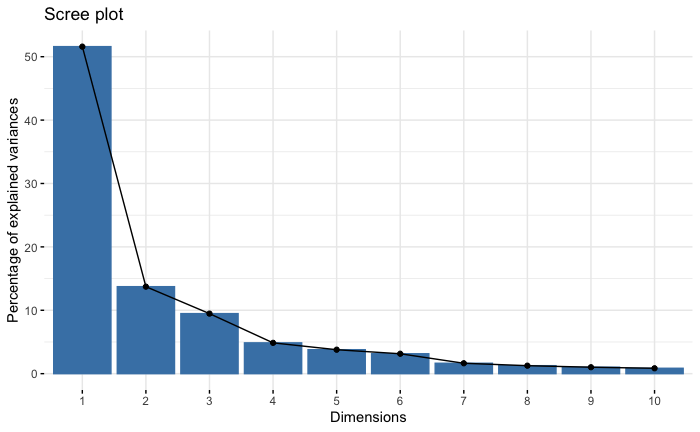

```r
# code here - include as many chunks of code as needed
fviz_screeplot(fifa18_pca)
```

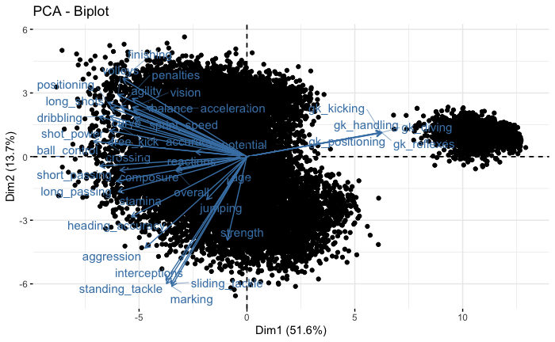

```r
fviz_pca(fifa18_pca,
         geom = "point",
         repel = TRUE)
```

# Problem 2

1. Read the Toyota Corollas dataset on sales during late summer of 2004 in the Netherlands. It has 1436 records containing details on 38 attributes, including Price, Age, Kilometers, HP, and other specifications.

```r
toyota <- read_csv("https://raw.githubusercontent.com/reisanar/datasets/master/ToyotaCorolla.csv")
```

- Print the first 6 rows of the dataset.

```r
head(toyota)
```

[output not shown]

- Identify (to the best of your knowledge) the categorical variables.

> Comments: `model`, `mfg_month`, `mfg_year`, `fuel_type`, `met_color`, `color`, `automatic`, `doors`, `cylinders`, `gears`, `mfr_guarantee`, `bovag_guarantee`, `guarantee_period`, `abs`, `airbag_1`, `airbag_2`, `airco`, `automatic_airco`, `board_computer`, `cd_player`, `central_lock`, `powered_windows`, `power_steering`, `radio`, `mistlamps`, `sport_model`, `backseat_driver`, `metallic_rim`, `radio_cassette`, `parking_assistant`, and `tow_bar` are all categorical variables. This doesn’t leave that many numerical variables!
2. Create a new data frame with some of the numerical attributes in this dataset (ignoring the categorical variables, and think about which variables are probably categorical variables even when represented by a number).

Perform **Principal Component Analysis (PCA)**, and **comment on your results**.

```r
# code here - include as many chunks of code as needed
# you could use the example above to select the collection of variables you want
my_toyota <- toyota %>%
              select(c(price, age_08_04, km, hp, cc, quarterly_tax, weight))
head(my_toyota)
```

| price | age_08_04 | km | hp | cc | quarterly_tax | weight |
| --- | --- | --- | --- | --- | --- | --- |
| 13500 | 23 | 46986 | 90 | 2000 | 210 | 1165 |
| 13750 | 23 | 72937 | 90 | 2000 | 210 | 1165 |
| 13950 | 24 | 41711 | 90 | 2000 | 210 | 1165 |
| 14950 | 26 | 48000 | 90 | 2000 | 210 | 1165 |
| 13750 | 30 | 38500 | 90 | 2000 | 210 | 1170 |
| 12950 | 32 | 61000 | 90 | 2000 | 210 | 1170 |

```r
# code here - include as many chunks of code as needed
my_toyota_pca <- prcomp(my_toyota, scale = T)
summary(my_toyota_pca)
```

```
Importance of components:
                          PC1    PC2    PC3     PC4     PC5     PC6     PC7
Standard deviation     1.6795 1.3789 0.9748 0.80717 0.58426 0.49700 0.29634
Proportion of Variance 0.4029 0.2716 0.1358 0.09307 0.04877 0.03529 0.01255
Cumulative Proportion  0.4029 0.6746 0.8103 0.90340 0.95217 0.98745 1.00000
```

> Comments: In a dataset with 7 usable variables, we are able to capture ~90% of the variation using only the first 4 principal components. This is not quite as impressive as the FIFA dataset, but still useful. Let’s try to learn more about our data:

```r
my_toyota_pca$rotation[ , 1:7]
```

```
                     PC1        PC2        PC3          PC4          PC5         PC6         PC7
price         -0.5631804 -0.1187984  0.1091575 -0.005011541  0.192642466 -0.02785284 -0.78669397
age_08_04      0.5229280  0.1015560 -0.2525609 -0.164011821 -0.527435206  0.18550886 -0.55941428
km             0.3190482  0.4844470 -0.1114305 -0.347847849  0.714502759 -0.01268993 -0.13938890
hp            -0.1889888 -0.3846308 -0.6518439 -0.543802358 -0.003764139 -0.28694250  0.11563199
cc            -0.1716474  0.3451950 -0.6754843  0.627031988  0.038998856 -0.01087641 -0.01703454
quarterly_tax -0.2246839  0.5897247  0.1641538 -0.196158754 -0.375475980 -0.62821410  0.02611666
weight        -0.4380867  0.3549772 -0.0612771 -0.353140913 -0.177959263  0.69824236  0.18546157
```

3. Produce at least one **data visualization** to explain the results on PCA. (You can use the `factoextra` package for this and follow the examples discussed in class)

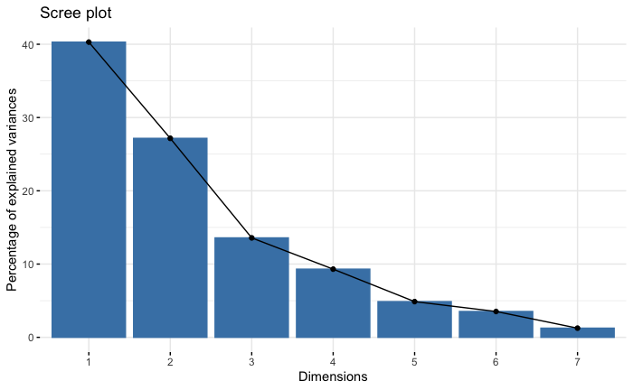

```r
# code here - include as many chunks of code as needed
fviz_screeplot(my_toyota_pca)
```

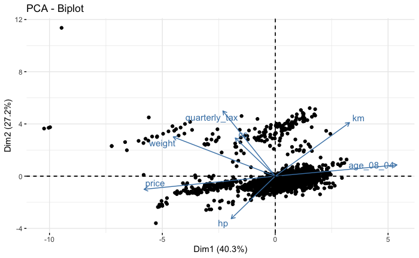

```r
fviz_pca_biplot(my_toyota_pca,
                geom = "point",
                repel = TRUE)
```

> According to the loadings, the first principal component weighs age and mileage positively, with price and weight being negative. The second principal component weighs quarterly tax, mileage, weight, and cc, with horsepower being weighted negatively. Our biplot shows some interesting correlations worth mentioning: age and mileage have a negative correlation with price, weight, cc, and quarterly tax have a positive correlation, and mileage and horsepower are negatively correlated. Do cars with more horsepower tend to not last as long? It could be worth investigating.

## Problem 3

> **Required for graduate students. Extra-credit (+10 points) for undergraduate students)**

You will use data generated by the Spotify API on songs nominated to the *Grammy Award for Song of the Year*.

Find the data in this [GitHub repo](https://github.com/reisanar/datasets/blob/master/grammy_softy_20.csv), and read it into RStudio using:

```r
# read grammy data
soty <- read_csv("https://raw.githubusercontent.com/reisanar/datasets/master/grammy_softy_20.csv")
```

1. Perform PCA on this dataset, using all the **numerical attributes** available.
2. Summarize your findings and comment on your results.
3. Apply PCA again to a smaller number of numerical attributes (briefly explain your reasoning for the selection of the numerical attributes you consider for this part of the problem)
4. Create at least one data visualization of your PCA results.